# Final Project

Author

Ryan Fernald, Eden Kidane

```r
library(tidyverse)
library(ggplot2)
library(ggthemes)
library(patchwork)
```

```r
x <- "https://raw.githubusercontent.com/ryanfernald/MATH167R-Final-Project/main/DATA/smartphone_usage_time_and_health_variable_outcomes.csv"

data <- read.csv(x)

head(data)
```

```
  Usage Stress_perception Stress_percentage_interval Sleep_dissatisfaction
1 0-0 h              1.00                       <NA>                  1.00
2 0-2 h              0.70                (0.62-0.79)                  0.73
3 2-4 h              0.71                (0.64-0.79)                  0.90
4 4-6 h              0.87                (0.77-0.97)                  1.08
5 6-8 h              1.04               (0.93-1.17)                   1.22
6  8+ h              1.28               (1.14-1.43)                   1.39
  Sleep_dissatisfaction_interval Depressive_symptoms
1                           <NA>                1.00
2                      0.62-0.79                0.62
3                      0.80-1.00                0.66
4                      0.96-1.21                0.82
5                      1.08-1.38                0.99
6                      1.23-1.57                1.30
  Depressive_symptoms_interval Suicidal_idea Suicidal_idea_interval
```

[output cut: 34 more lines]

```r
filtered_data <- data[, c(1:2, seq(4, ncol(data), by = 2))]
head(filtered_data)
```

```
  Usage Stress_perception Sleep_dissatisfaction Depressive_symptoms
1 0-0 h              1.00                  1.00                1.00
2 0-2 h              0.70                  0.73                0.62
3 2-4 h              0.71                  0.90                0.66
4 4-6 h              0.87                  1.08                0.82
5 6-8 h              1.04                  1.22                0.99
6  8+ h              1.28                  1.39                1.30
  Suicidal_idea Suicidal_plan Suicidal_attempt Alcohol Smoking
1          1.00          1.00             1.00    1.00    1.00
2          0.57          0.44             0.27    0.53    0.30
3          0.60          0.40             0.23    0.73    0.45
4          0.70          0.45             0.29    1.00    0.62
5          0.97          0.65             0.49    1.26    0.81
6          1.23          0.83             0.66    1.79    1.47
  Smartphone_overdependence Obesity
1                      1.00    1.00
2                      0.90    1.00
3                      1.67    0.96
4                      2.55    0.93
5                      3.57    0.97
6                      4.41    1.04
```

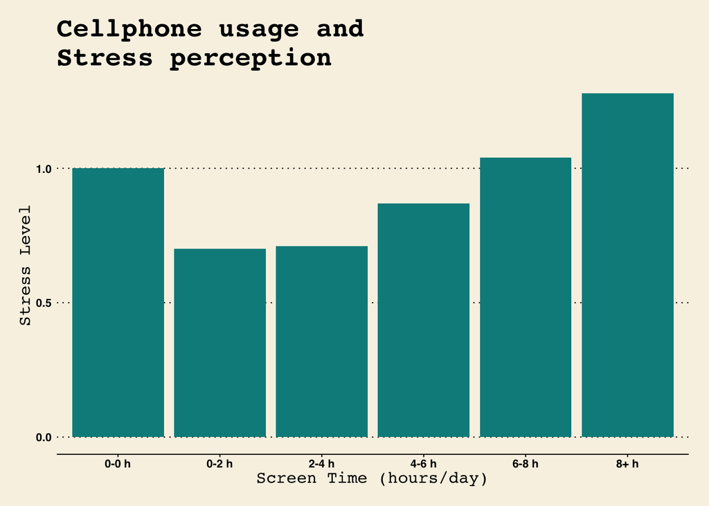

```r
ggplot(data = filtered_data, aes(x = Usage,
                                 y = Stress_perception)) +
  geom_bar(stat = "identity", fill = "darkcyan") +
  theme_wsj(base_size = 8) +
      theme(axis.title=element_text(size=12)) +
  labs(title = "Cellphone usage and \nStress perception",
       x = "Screen Time (hours/day)",
       y = "Stress Level")
```

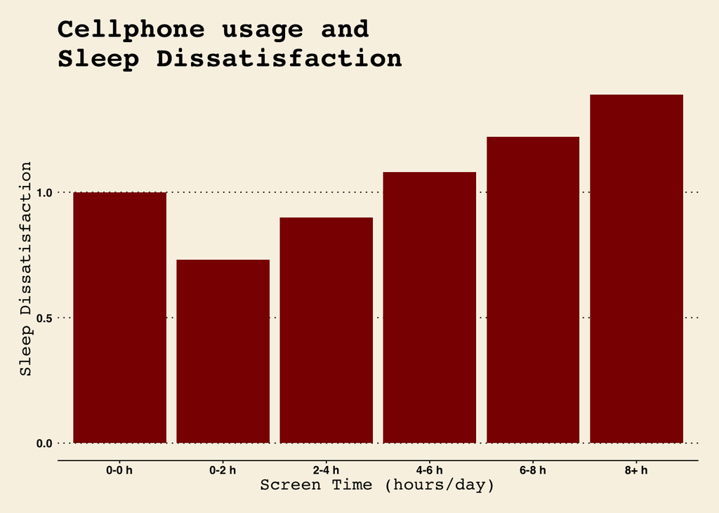

```r
ggplot(data = filtered_data, aes(x = Usage,
                                 y = Sleep_dissatisfaction)) +
  geom_bar(stat = "identity", fill = "darkred") +
  theme_wsj(base_size = 8) +
      theme(axis.title=element_text(size=12)) +
  labs(title = "Cellphone usage and \nSleep Dissatisfaction",
       x = "Screen Time (hours/day)",
       y = "Sleep Dissatisfaction")
```

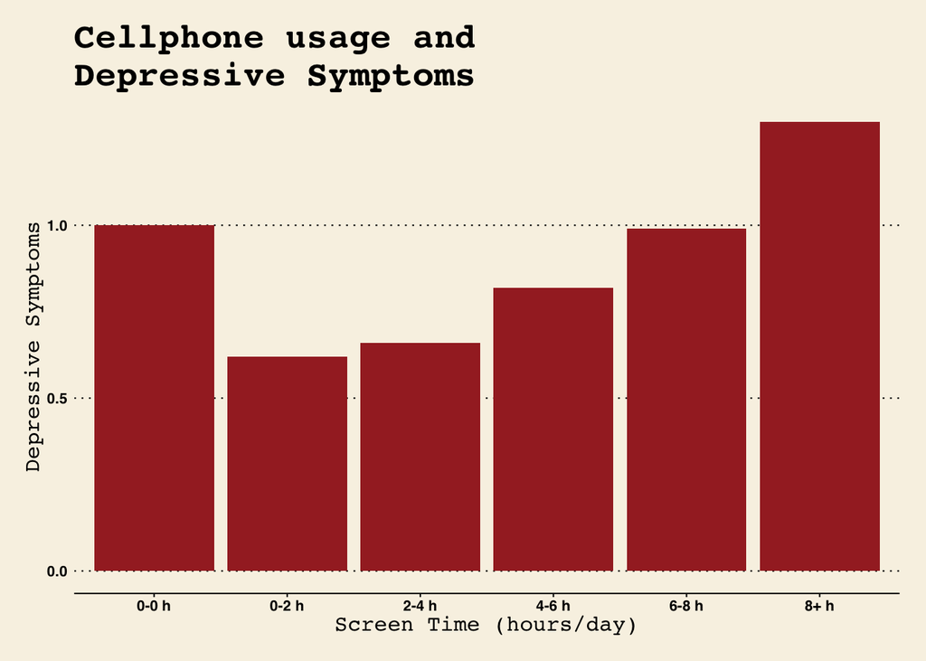

```r
ggplot(data = filtered_data, aes(x = Usage,
                                 y = Depressive_symptoms)) +
  geom_bar(stat = "identity", fill = "brown") +
  theme_wsj(base_size = 8) +
      theme(axis.title=element_text(size=12)) +
  labs(title = "Cellphone usage and \nDepressive Symptoms",
       x = "Screen Time (hours/day)",
       y = "Depressive Symptoms")
```

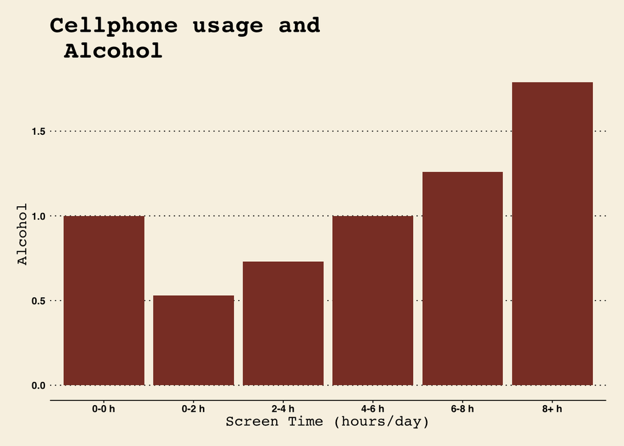

```r
ggplot(data = filtered_data, aes(x = Usage,
                                 y = Alcohol)) +
  geom_bar(stat = "identity", fill = "coral4") +
  theme_wsj(base_size = 8) +
      theme(axis.title=element_text(size=12)) +
  labs(title = "Cellphone usage and \n Alcohol",
       x = "Screen Time (hours/day)",
       y = "Alcohol")
```

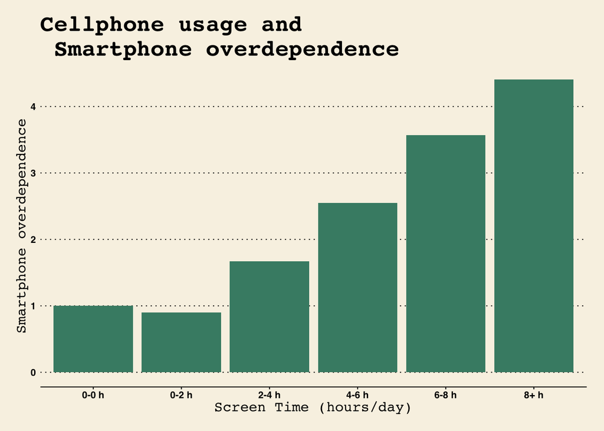

```r
ggplot(data = filtered_data, aes(x = Usage,
                                 y = Smartphone_overdependence)) +
  geom_bar(stat = "identity", fill = "aquamarine4") +
  theme_wsj(base_size = 8) +
      theme(axis.title=element_text(size=12)) +
  labs(title = "Cellphone usage and \n Smartphone overdependence",
       x = "Screen Time (hours/day)",
       y = "Smartphone overdependence")
```

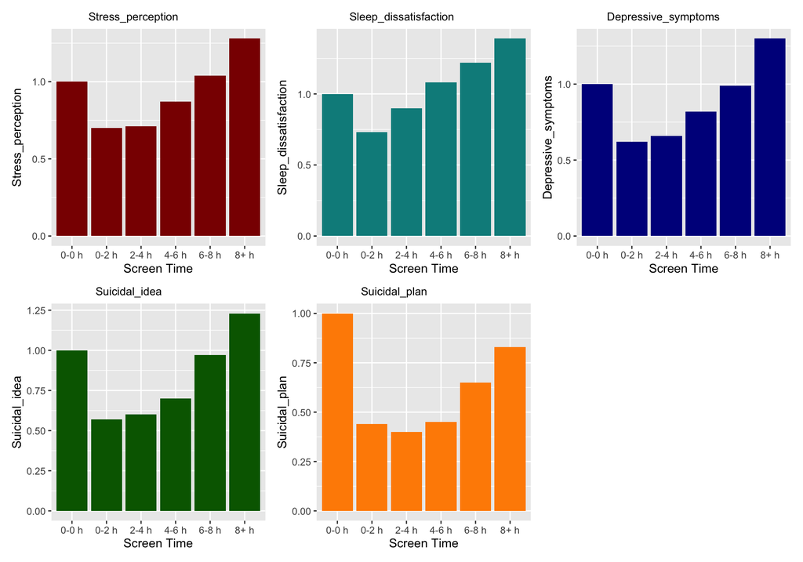

```r
colors <- c("darkred", "darkcyan", "darkblue", "darkgreen", "darkorange", "purple", "darkgray", "darkmagenta", "darkolivegreen", "darkslategray")

vars_set1 <- names(filtered_data)[-1][1:5]
vars_set2 <- names(filtered_data)[-1][6:10]

create_plots <- function(vars, title_prefix) {
  plots <- lapply(vars, function(var) {
    ggplot(data = filtered_data, aes_string(x = "Usage", y = var)) +
      geom_bar(stat = "identity", fill = colors[match(var, names(filtered_data)[-1])]) +
      labs(x = "Screen Time",
           y = var) +
      theme(plot.title = element_text(hjust = 0.3, size = 10)) +
      ggtitle(paste(var))
  })
  multiplot <- wrap_plots(plots, nrow = 2, width = 10, height = 10)
  return(multiplot)
}

multiplot_set1 <- create_plots(vars_set1, "Set 1:")

multiplot_set2 <- create_plots(vars_set2, "Set 2:")

multiplot_set1
```

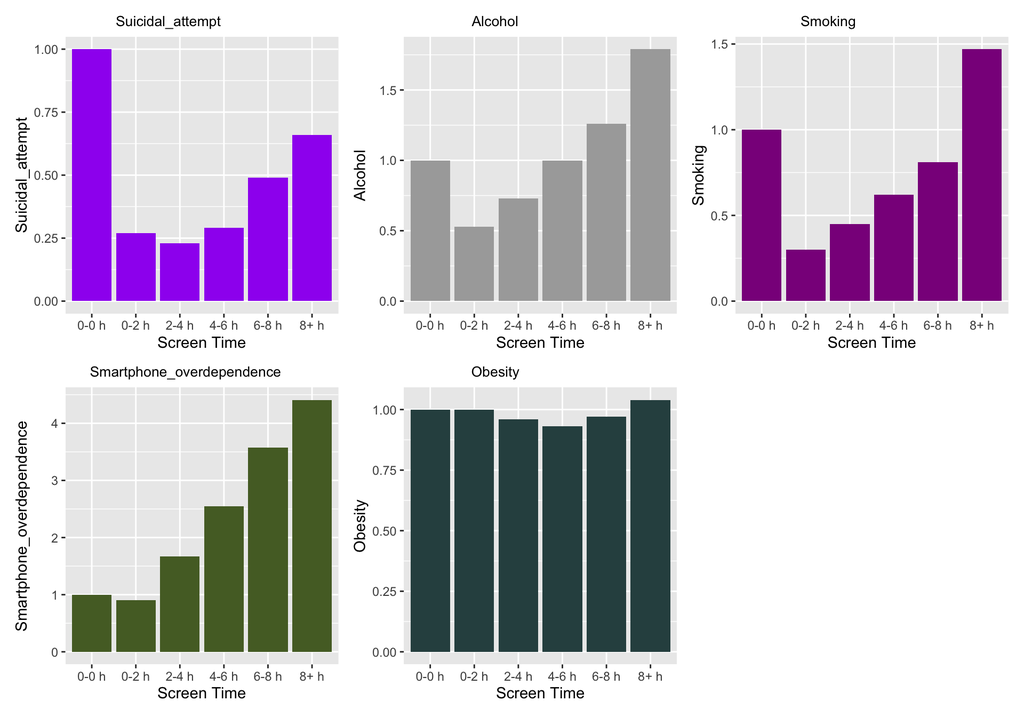

```r
multiplot_set2
```

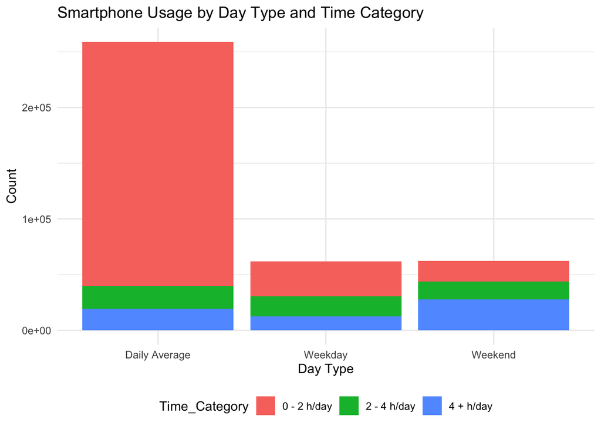

```r
data <- data.frame(
Day_type = c(rep("Weekday", 3), rep("Weekend", 3), rep("Daily Average", 3)),
Time_Category = rep(c("0 - 2 h/day", "2 - 4 h/day", "4 + h/day"), 3),
Count = c(31481, 17775, 12605, 18713, 15778, 27910, 218763, 20568, 19420)
)
# Bar Plot
bar_plot <- ggplot(data, aes(x = Day_type, y = Count, fill = Time_Category)) +
geom_bar(stat = "identity") +
labs(title = "Smartphone Usage by Day Type and Time Category",
x = "Day Type",
y = "Count") +
theme_minimal() +
theme(legend.position = "bottom")
# Stacked Bar Plot
stacked_bar_plot <- ggplot(data, aes(x = Day_type, y = Count, fill = Time_Category)) +
geom_bar(stat = "identity") +
labs(title = "Smartphone Usage by Day Type and Time Category",
x = "Day Type",
y = "Count") +
theme_minimal() +
theme(legend.position = "bottom") +
coord_flip()


# Pie Chart
pie_chart <- ggplot(data, aes(x = "", y = Count, fill = Time_Category)) +
geom_bar(stat = "identity", width = 1) +
coord_polar("y", start = 0) +
labs(title = "Proportion of Smartphone Usage by Time Category",
x = NULL,
y = NULL) +
theme_void() +
theme(legend.position = "right")
# Display the graphs
print(bar_plot)
```

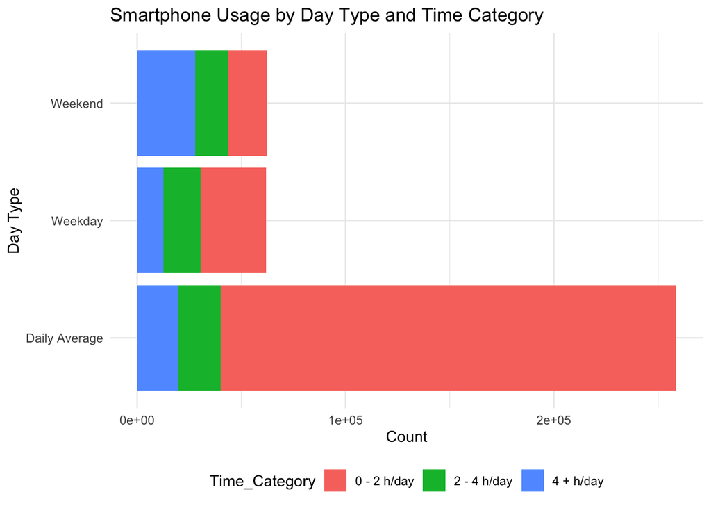

```r
print(stacked_bar_plot)
```

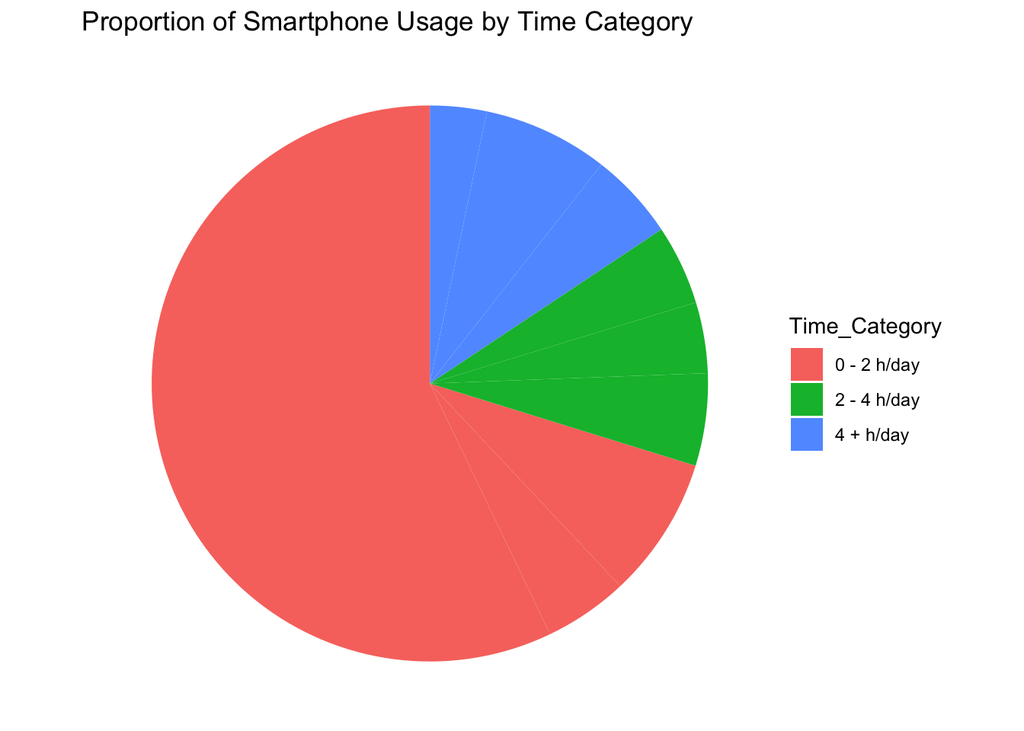

```r
print(pie_chart)
```

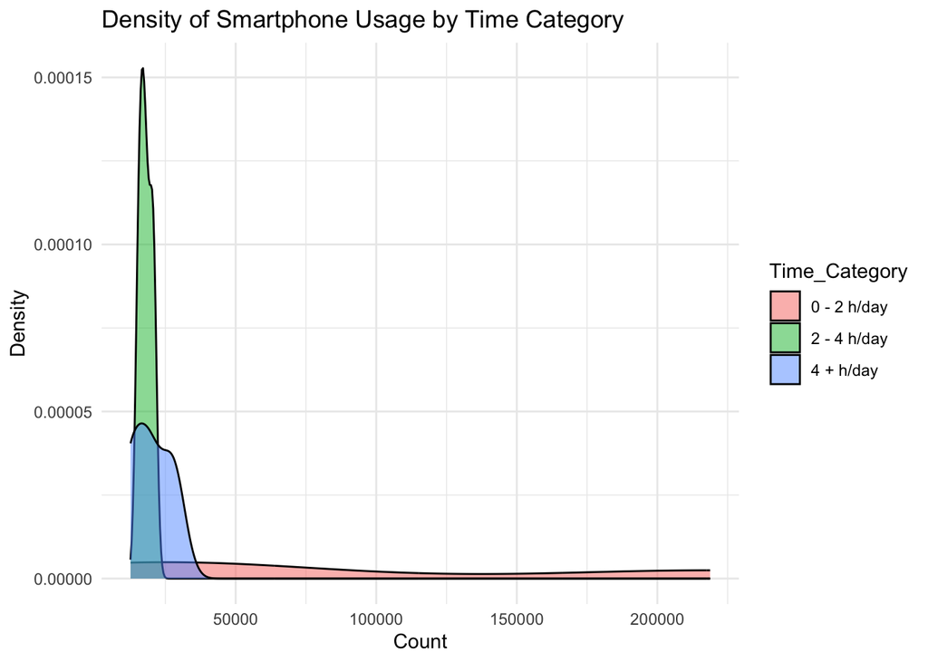

```r
library(ggplot2)
# Create a dataframe with the data
data <- data.frame(
Day_type = c(rep("Weekday", 3), rep("Weekend", 3), rep("Daily Average", 3)),
Time_Category = rep(c("0 - 2 h/day", "2 - 4 h/day", "4 + h/day"), 3),
Count = c(31481, 17775, 12605, 18713, 15778, 27910, 218763, 20568, 19420)
)

library(ggplot2)
# Create a dataframe with the data
data <- data.frame(
Day_type = c(rep("Weekday", 3), rep("Weekend", 3), rep("Daily Average", 3)),
Time_Category = rep(c("0 - 2 h/day", "2 - 4 h/day", "4 + h/day"), 3),
Count = c(31481, 17775, 12605, 18713, 15778, 27910, 218763, 20568, 19420)
)

# Density Plot
density_plot <- ggplot(data, aes(x = Count, fill = Time_Category)) +
geom_density(alpha = 0.5) +
labs(title = "Density of Smartphone Usage by Time Category",
x = "Count",
y = "Density") +
theme_minimal()
print(density_plot)
```

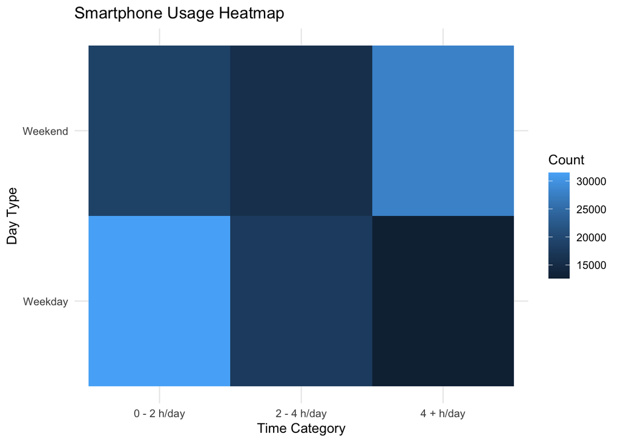

```r
library(ggplot2)
# Create a dataframe with the data
data <- data.frame(
Day_type = c(rep("Weekday", 3), rep("Weekend", 3), rep("Daily Average", 3)),
Time_Category = rep(c("0 - 2 h/day", "2 - 4 h/day", "4 + h/day"), 3),
Count = c(31481, 17775, 12605, 18713, 15778, 27910, 218763, 20568, 19420)
)


# Remove Daily Average row for heatmap
no_daily <- data[data$Day_type != "Daily Average", ]

# Heatmap
heatmap <- ggplot(no_daily, aes(x = Time_Category, y = Day_type, fill = Count)) +
geom_tile() +
labs(title = "Smartphone Usage Heatmap",
x = "Time Category",
y = "Day Type",
fill = "Count") +
theme_minimal()
print(heatmap)
```

```r
# Convert data to wide format for heatmap
library(tidyr)
library(ggplot2)
# Create a dataframe with the data
data <- data.frame(
Day_type = c(rep("Weekday", 3), rep("Weekend", 3), rep("Daily Average", 3)),
Time_Category = rep(c("0 - 2 h/day", "2 - 4 h/day", "4 + h/day"), 3),
Count = c(31481, 17775, 12605, 18713, 15778, 27910, 218763, 20568, 19420)
)
```

```r
h <- "https://raw.githubusercontent.com/ryanfernald/MATH167R-Final-Project/main/DATA/Percentages%20stats%20health%20outcomes.csv"
data <- read.csv(h)
```

```r
data_long <- data |>
  pivot_longer(cols = -Usage,
               names_to = "Health_Outcome",
               values_to = "Percentage")

data_long$Health_Outcome <- factor(data_long$Health_Outcome, levels = unique(data_long$Health_Outcome))
```

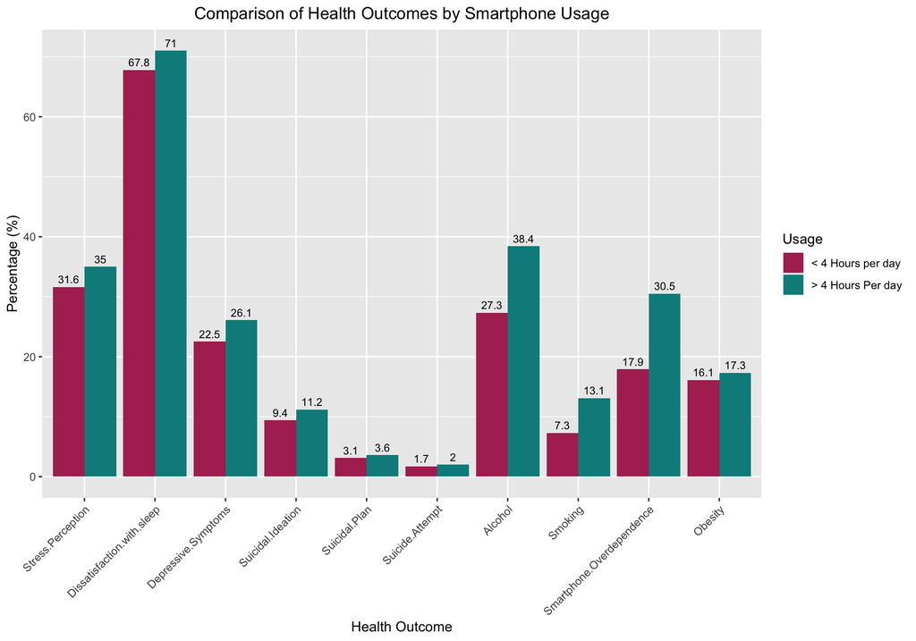

```r
ggplot(data_long, aes(x = Health_Outcome, y = Percentage, fill = Usage, label = Percentage)) +
  geom_bar(stat = "identity", position = "dodge") +
  geom_text(position = position_dodge(width = 0.9), size = 3, vjust = -0.5) +  # Add labels directly on top of bars with dodge position
  scale_fill_manual(values = c("< 4 Hours per day" = "maroon", "> 4 Hours Per day" = "darkcyan")) +
  labs(
    title = "Comparison of Health Outcomes by Smartphone Usage",
    x = "Health Outcome",
    y = "Percentage (%)"
  ) +
  theme(
    axis.text.x = element_text(angle = 45, hjust = 1),
    plot.title = element_text(hjust = 0.5)
  )
```

# Inferential analysis

## Research Question: What are the health risks associated with excessive smartphone and social media use leading to isolation, and how does this impact different demographic groups in terms of social interactions and behaviors?

### Findings:

The study conducted by Matar Boumosleh and Daniel Jaalouk (2017) explored the relationship between excessive smartphone usage, addiction metrics, and mental health outcomes among university students.The study found a significant association between excessive smartphone usage and symptoms of depression and anxiety among university students. This suggests that students who reported spending more time on their smartphones were more likely to experience higher levels of depression and anxiety.The researchers used the Smartphone Addiction Inventory (SPAI) Scale to measure smartphone addiction among participants. They found that higher scores on the SPAI Scale, indicating greater levels of smartphone addiction, were correlated with higher levels of depression and anxiety.

To test this we have a variety of features in our data which we can use to create linear regression models such as excessive smartphone usage, restlessness symptoms without smartphone, and decreased sleep time, and quality due to smartphone use.

```r
w <- "https://raw.githubusercontent.com/ryanfernald/MATH167R-Final-Project/main/DATA/Depression%2C%20anxiety%2C%20and%20smartphone%20addiction%20in%20university%20students-%20A%20cross%20sectional%20study.csv"
wdata <- read.csv(w)
wdata[wdata == "."] <- NA
```

[figure not shown]

```r
ggplot(wdata, aes(y = as.numeric(TotAddiction_Score),
                  x = as.numeric(ExcessveSmrtPhn_Use))) +
  geom_point(aes(color = "maroon"), alpha = 0.4) +
  geom_smooth(aes(color = "maroon"), method = "lm") +

  geom_point(aes(x = as.numeric(Rstlss_NoSmrtphn),
                 color = "darkcyan"), alpha = 0.4) +
  geom_smooth(aes(x = as.numeric(Rstlss_NoSmrtphn),
                  color = "darkcyan"), method = "lm") +

  geom_point(aes(x = as.numeric(DcreasdSlpTimeQulty_SmrtPhnUse),
                 color = "darkgoldenrod"), alpha = 0.4) +
  geom_smooth(aes(x = as.numeric(DcreasdSlpTimeQulty_SmrtPhnUse),
                  color = "darkgoldenrod"), method = "lm") +

  labs(
    title = "Regression Model of Smartphone Usage and Addiction",
    x = "Smartphone Usage Categories",
    y = "Total Addiction Score",
    color = "Category"
  ) +
  scale_color_manual(values = c("maroon", "darkcyan", "darkgoldenrod"),
                     labels = c("Excessive Smartphone Usage",
                                "Restlessness without Smartphone",
                                "Decreased Sleep Time Quality due to Smartphone Use")) +
  theme(legend.position = "right")
```

```r
# lm_model_1 <- lm(as.numeric(TotAddiction_Score) ~
#                  as.numeric(ExcessveSmrtPhn_Use),
#                  data = wdata, na.action = na.exclude)
# summary(lm_model_1)
#
# lm_model_2 <- lm(as.numeric(TotAddiction_Score) ~
#                  as.numeric(Rstlss_NoSmrtphn),
#                  data = wdata, na.action = na.exclude)
# lm_model_2
#
# lm_model_3 <- lm(as.numeric(TotAddiction_Score) ~ as.numeric(DcreasdSlpTimeQulty_SmrtPhnUse),
#                  xdata = wdata, na.action = na.exclude)
# lm_model_3

lm_model_combined <- lm(as.numeric(TotAddiction_Score) ~
                        as.numeric(ExcessveSmrtPhn_Use) +
                        as.numeric(Rstlss_NoSmrtphn) +
                        as.numeric(DcreasdSlpTimeQulty_SmrtPhnUse),
                        data = wdata, na.action = na.exclude)
summary(lm_model_combined)
```

```
Call:
lm(formula = as.numeric(TotAddiction_Score) ~ as.numeric(ExcessveSmrtPhn_Use) +
    as.numeric(Rstlss_NoSmrtphn) + as.numeric(DcreasdSlpTimeQulty_SmrtPhnUse),
    data = wdata, na.action = na.exclude)

Residuals:
     Min       1Q   Median       3Q      Max
-25.4707  -5.0014  -0.0699   4.8364  22.6955

Coefficients:
                                           Estimate Std. Error t value Pr(>|t|)
(Intercept)                                 13.6330     1.1687  11.665   <2e-16
as.numeric(ExcessveSmrtPhn_Use)              3.8259     0.3954   9.675   <2e-16
as.numeric(Rstlss_NoSmrtphn)                 6.1905     0.4083  15.163   <2e-16
as.numeric(DcreasdSlpTimeQulty_SmrtPhnUse)   8.6597     0.4419  19.599   <2e-16

(Intercept)                                ***
as.numeric(ExcessveSmrtPhn_Use)            ***
as.numeric(Rstlss_NoSmrtphn)               ***
as.numeric(DcreasdSlpTimeQulty_SmrtPhnUse) ***
---
Signif. codes:  0 '***' 0.001 '**' 0.01 '*' 0.05 '.' 0.1 ' ' 1

Residual standard error: 7.341 on 456 degrees of freedom
  (228 observations deleted due to missingness)
Multiple R-squared:  0.7644,    Adjusted R-squared:  0.7628
F-statistic: 493.2 on 3 and 456 DF,  p-value: < 2.2e-16
```

#### Why we chose this model

We chose a linear regression model because our data has categorical data represented on a scale from 1 to 4 where 1 is the least extreme, and 4 is the most. We can interpret this as higher levels of $X_i$ leads to higher levels in our Response Variable $Y$.

Given our response $Y$ and our predictors $X_1,…,X_p$ where,

$Y = \beta_0 + \beta_1 X_1 + \beta_2 X_2 + \beta_3 X_3 + \epsilon$ and,

$\epsilon \sim N(O, \sigma^2)$

$\beta_0$ is the intercept. $\beta_1$ is ExcessveSmrtPhn_Use $\beta_2$ is Rstlss_NoSmrtphn $\beta_3$ is DcreasdSlpTimeQulty_SmrtPhnUse

#### What is the model, What x is and y

The model is a linear regression model that predicts the total addiction score (y) based on one or more independent variables (x), such as excessive smartphone usage, restlessness without smartphone, and decreased sleep time quality due to smartphone use.

$X$ is our Independent Variables, where $Y$ is our Dependent Variable, or Response Variable.

#### Hypothesis Testing

For each of our variables, we can get the information from hypothesis testing form the summary.

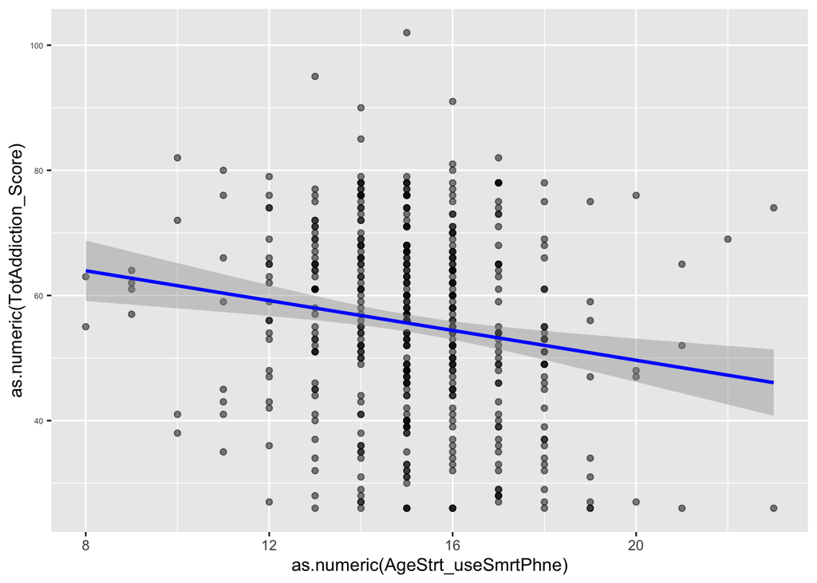

```r
ggplot(wdata, aes(x = as.numeric(AgeStrt_useSmrtPhne),
                  y = as.numeric(TotAddiction_Score))) +
  geom_point(alpha = 0.5) +
  geom_smooth(method = "lm", color = "blue")+
  theme(axis.text.y=element_text(size=5))
```

```r
lm_model <- lm(as.numeric(AgeStrt_useSmrtPhne) ~
               as.numeric(TotAddiction_Score),
               data = wdata, na.action = na.exclude)
lm_model
```

```
Call:
lm(formula = as.numeric(AgeStrt_useSmrtPhne) ~ as.numeric(TotAddiction_Score),
    data = wdata, na.action = na.exclude)

Coefficients:
                   (Intercept)  as.numeric(TotAddiction_Score)
                      16.41610                        -0.02331
```

# Refrences

Matar Boumosleh J, Jaalouk D (2017) Depression, anxiety, and smartphone addiction in university students- A cross sectional study. PLOS ONE 12(8): e0182239. https://doi.org/10.1371/journal.pone.0182239

Simó-Sanz C, Ballestar-Tarín MªL, Martínez-Sabater A. Smartphone Addiction Inventory (SPAI): Translation, adaptation and validation of the tool in Spanish adult population. PLoS One. 2018 Oct 17;13(10):e0205389. doi: 10.1371/journal.pone.0205389. PMID: 30332481; PMCID: PMC6192628.

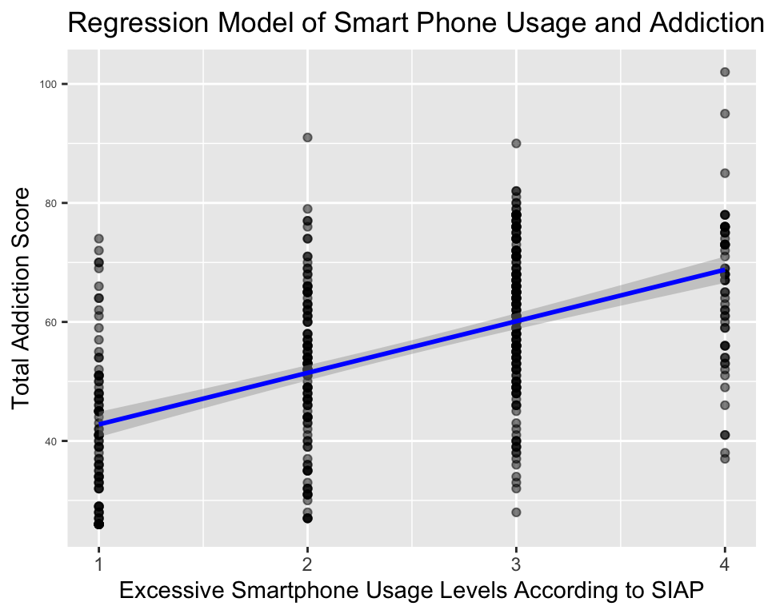

```r
ggplot(wdata, aes(y = as.numeric(TotAddiction_Score), x = as.numeric(ExcessveSmrtPhn_Use))) +
  geom_point(alpha = 0.5) +
  labs(
    title = "Regression Model of Smart Phone Usage and Addiction",
    x = "Excessive Smartphone Usage Levels According to SIAP",
    y = "Total Addiction Score"
  ) +
  geom_smooth(method = "lm", color = "blue")+theme(axis.text.y=element_text(size=5))
```